# Edited_CIND830 - Summer 23 - Assignment 2

## CIND830 - Python Programming for Data Science

### Assignment 2 (15% of the final grade)

### Due on Aug 9th, 2023 11:59 PM

This is a Jupyter Notebook document that extends a simple formatting syntax for authoring HTML and PDF. Review [this](https://jupyter-notebook.readthedocs.io/en/stable/notebook.html) website for more details on using Jupyter Notebooks.

Consider using a Jupyter Notebook or Google Colab platform to complete this assignment. Ensure using **Python 3.7 release or higher** then complete the assignment by inserting your Python code wherever seeing the string `#INSERT YOUR ANSWER HERE.`

You are expected to submit the notebook file (in IPYNB format) and the exported version (either in PDF or HTML) in the same Assignment link in D2L. Use [these](https://www.torontomu.ca/courses/students/tutorials/assignments/) guidelines to submit **both** the IPYNB and the exported file (HTML or PDF). Failing to submit both files will be subject to mark deduction.

Please be advised that you cannot get more than 100% in this assignment, and the **BONUS** question (if there is any) will only be graded if all other questions have been submitted.

Coverage:

1. Lists, Tuples and Dictionaries
2. Functions and Classes
3. Searching and Sorting
4. Arrays and Grids
5. Stacks, Queues, and Lists

### Question 1 **[30 pts]**:

[Pascal's triangle](https://en.wikipedia.org/wiki/Pascal%27s_triangle) is a triangular array that can be used to find combinations. Each number in the triangle is the sum of the two numbers above it. For example, the value 4 in row 4 is the sum of 1 and 3 in the row above. The first and last number in any row will always be 1.

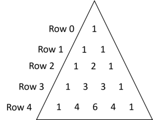

The value of a row and column in Pascal's Triangle can be calculated using the following formula: $$C(n, r) = \frac{n!}{r! (n-r)!}$$ where $n$ and $r$, are the row and column indices.

For example, $C(4,2) = 6$ corresponds to row index 4 and column index 2.

**Question 1.a [10 pts]**: Design a function that takes the row id and column id as arguments and returns the corresponding value from Pascal's triangle. Hint: You can use the [math.factorial()](https://docs.python.org/3/library/math.html#math.factorial) function or design one to compute the factorials.

Make sure you name your function correctly so that the test code in the section below your answer can run.

```python
### ANSWER HERE
import math

def find_c(row, column):
    if row < 0 or column < 0 or column > row:
        return None

    com = math.factorial(row) // (math.factorial(column) * math.factorial(row - column))
    return com
```

```python
# DO NOT MODIFY THE FOLLOWING PART
# When the following code is executed it needs to produce the correct output
print(find_c(4,2))
print(find_c(5,3))
print(find_c(10,0))
```

```
6
10
1
```

```
[[1], [1, 1], [1, 2, 1], [1, 3, 3, 1], [1, 4, 6, 4, 1], [1, 5, 10, 10, 5, 1], [1, 6, 15, 20, 15, 6, 1]]
```

Make sure you name your function correctly so that the test code in the section below your answer can run.

Remember, the n rows of a Pascal triangle would look like the below if you draw it as a triangle. But the question asks to produce the above list.

```
        1
       1 1
      1 2 1
     1 3 3 1
    1 4 6 4 1
   1 5 10 10 5 1
  1 6 15 20 15 6 1
```

**Hint**: You can use the function you designed in part a to compute the triangle values.

```python
### ANSWER HERE
def create_pascal_triangle(n):
    triangle = []
    for row in range(n):
        current_row = [find_c(row, column) for column in range(row + 1)]
        triangle.append(current_row)
    return triangle
```

```python
# DO NOT MODIFY THE FOLLOWING PART
# When the following code is executed it needs to produce the correct output
print(create_pascal_triangle(7))
```

```
[[1], [1, 1], [1, 2, 1], [1, 3, 3, 1], [1, 4, 6, 4, 1], [1, 5, 10, 10, 5, 1], [1, 6, 15, 20, 15, 6, 1]]
```

**Question 1.c [10 pts]**: Design a function that flips the Pascal triangle. For example, if the user calls the function with 6 as an argument, the output would be as follows.

```
1 5 10 10 5 1
  1 4 6 4 1
   1 3 3 1
    1 2 1
     1 1
      1
```

Make sure you name your function correctly so that the test code in the section below your answer can run.

**Hint**: You can use the function you designed in part a to compute the triangle values.

```python
### ANSWER HERE
def print_flipped_pascal_triangle(n):
    for row in range(n):
        print(" " * row, end="")
        for column in range(n - row):
            value = find_c(n - 1 - row, column)
            print(value, end=" ")
        print()
```

```python
# DO NOT MODIFY THE FOLLOWING PART
# When the following code is executed it needs to produce the correct output
print_flipped_pascal_triangle(6)
```

```
1 5 10 10 5 1
 1 4 6 4 1
  1 3 3 1
   1 2 1
    1 1
     1
```

### Question 2 **[30 pts]**:

**E-commerce Store**

Suppose you are building a simplified backend system for an e-commerce store.

You are expected to define a number of classes and objects, then create the relevant test case functions to check your results.

A sample test case function is given in *Question 2.a*

**Question 2.a [10 pts]**:

Define a class `Product` with attributes `name` and `price`.

The class should also have a method `update_price` that allows the price to be updated

You should add a test case to check your results.

A sample test case function for this question should look like;

```
# Test Case for Question 1a
def test_product():
    p1 = Product("Apple", 100)
    assert p1.name == "Apple"
    assert p1.price == 100
    print(vars(p1))

    # Update price
    p1.update_price(110)
    assert p1.price == 110
    print(vars(p1))

    print("All Product tests passed")

test_product()
```

Make sure you name your function correctly so that the test code in the section below your answer can run.

```python
## ANSWER HERE
class Product:
    def __init__(self, name, price):
        self.name = name
        self.price = price

    def update_price(self, new_price):
        self.price = new_price
```

```python
# DO NOT MODIFY THE FOLLOWING PART
# When the following code is executed it needs to produce the correct output

# Test Case for Question 1a
def test_product():
    p1 = Product("Apple", 100)
    assert p1.name == "Apple"
    assert p1.price == 100
    print(vars(p1))

    # Update price
    p1.update_price(110)
    assert p1.price == 110
    print(vars(p1))

    print("All Product tests passed")

test_product()
```

```
{'name': 'Apple', 'price': 100}
{'name': 'Apple', 'price': 110}
All Product tests passed
```

**Question 2.b [10 pts]**:

Create a class `Customer` with attributes `name` and `cart`.

`cart` should be a dictionary with `Product` instances as keys and quantities as values.

This class should have the following methods:

- `add_to_cart(Product, quantity)`: this should add the product to the customer's cart, updating the quantity in the cart.
- `remove_from_cart(Product, quantity)`: this should remove the product from the customer's cart, updating the quantity in the cart.
- `checkout()`: this should calculate and return the total cost of all products in the cart.
- `empty_cart()`: this empties all products from the customer's cart

Business Rules:

- If the quantity of the cart item is 0, then the entry of the cart should be removed.
- You cannot remove a quantity that doesn't exist in the cart
- You cannot remove a product that is not in the cart
- For the current question we can assume that there is unlimited number of products in the store

Make sure you name your function correctly so that the test code in the section below your answer can run.

```python
## ANSWER HERE
class Customer:
    def __init__(self, name):
        self.name = name
        self.cart = {}

    def add_to_cart(self, product, quantity):
        if quantity > 0:
            if product in self.cart:
                self.cart[product] += quantity
            else:
                self.cart[product] = quantity

    def remove_from_cart(self, product, quantity):
        if product in self.cart and self.cart[product] >= quantity:
            self.cart[product] -= quantity
            if self.cart[product] == 0:
                del self.cart[product]

    def checkout(self):
        total_cost = sum(product.price * quantity for product, quantity in self.cart.items())
        return total_cost

    def empty_cart(self):
        self.cart = {}
```

```python
# DO NOT MODIFY THE FOLLOWING PART
# When the following code is executed it needs to produce the correct output

# Test Case for Question 1b
def test_customer():
    p1 = Product("Apple", 3)
    p2 = Product("Banana", 1)
    customer = Customer("John Doe")

    print(vars(p1))
    print(vars(p2))
    print(vars(customer))

    # Test add_to_cart
    customer.add_to_cart(p1, 10)
    assert customer.cart[p1] == 10
    print(vars(customer))

    customer.add_to_cart(p2, 20)
    assert customer.cart[p2] == 20
    print(vars(customer))

    # Test remove_from_cart
    customer.remove_from_cart(p1, 5)
    assert customer.cart[p1] == 5
    print(vars(customer))

    customer.remove_from_cart(p2, 10)
    assert customer.cart[p2] == 10
    print(vars(customer))

    # Test checkout
    total = customer.checkout()
    assert total == 5 * p1.price + 10 * p2.price
    print(vars(customer))

    # Test empty_cart
    customer.empty_cart()
    assert not bool(customer.cart)
    print(vars(customer))

    print("All test cases pass for Customer")


test_customer()
```

```
{'name': 'Apple', 'price': 3}
{'name': 'Banana', 'price': 1}
{'name': 'John Doe', 'cart': {}}
{'name': 'John Doe', 'cart': {<__main__.Product object at 0x7fe00154b4f0>: 10}}
{'name': 'John Doe', 'cart': {<__main__.Product object at 0x7fe00154b4f0>: 10, <__main__.Product object at 0x7fe00154b970>: 20}}
{'name': 'John Doe', 'cart': {<__main__.Product object at 0x7fe00154b4f0>: 5, <__main__.Product object at 0x7fe00154b970>: 20}}
{'name': 'John Doe', 'cart': {<__main__.Product object at 0x7fe00154b4f0>: 5, <__main__.Product object at 0x7fe00154b970>: 10}}
{'name': 'John Doe', 'cart': {<__main__.Product object at 0x7fe00154b4f0>: 5, <__main__.Product object at 0x7fe00154b970>: 10}}
{'name': 'John Doe', 'cart': {}}
All test cases pass for Customer
```

**Question 2.c [10 pts]**:

Create a class `Store` with attribute `inventory` (a dictionary of `Product` instances as keys, and with the stock quantities as values).

This class should have the following methods:

- `add_product(Product, stock_quantity)`: this should add the product to the store's inventory with the specified stock quantity. If the product already exists, then it needs to increase the stock quantity only.
- `remove_product(Product, stock_quantity)`: this should remove the product from the store's inventory with the specified stock quantity. It should not remove a stock quantity that doesn't exist in the stock, nor the product if it is not in the inventory

Make sure you name your function correctly so that the test code in the section below your answer can run.

```python
## ANSWER HERE
class Store:
    def __init__(self):
        self.inventory = {}

    def add_product(self, product, stock_quantity):
        if stock_quantity > 0:
            if product in self.inventory:
                self.inventory[product] += stock_quantity
            else:
                self.inventory[product] = stock_quantity

    def remove_product(self, product, stock_quantity):
        if product in self.inventory and self.inventory[product] >= stock_quantity:
            self.inventory[product] -= stock_quantity
            if self.inventory[product] == 0:
                del self.inventory[product]
```

```python
# DO NOT MODIFY THE FOLLOWING PART
# When the following code is executed it needs to produce the correct output

# Test Case for Question 1c
def test_store():
    p1 = Product("Apple", 3)
    p2 = Product("Banana", 1)
    p3 = Product("Cherry", 5)
    store = Store()

    print(vars(p1))
    print(vars(p2))
    print(vars(p3))
    print(vars(store))

    # Test add_product
    store.add_product(p1, 100)
    assert p1 in store.inventory
    assert store.inventory[p1] == 100
    print(vars(store))

    store.add_product(p2, 200)
    assert p2 in store.inventory
    assert store.inventory[p2] == 200
    print(vars(store))

    store.add_product(p3, 300)
    assert p3 in store.inventory
    assert store.inventory[p3] == 300
    print(vars(store))

    # Test remove_product
    store.remove_product(p1, 100)
    assert p1 not in store.inventory
    print(vars(store))

    store.add_product(p3, 100)
    assert p3 in store.inventory
    assert store.inventory[p3] == 400
    print(vars(store))

    print("All test cases pass for Store")

test_store()
```

```
{'name': 'Apple', 'price': 3}
{'name': 'Banana', 'price': 1}
{'name': 'Cherry', 'price': 5}
{'inventory': {}}
{'inventory': {<__main__.Product object at 0x7fe00154b490>: 100}}
{'inventory': {<__main__.Product object at 0x7fe00154b490>: 100, <__main__.Product object at 0x7fe00154bd60>: 200}}
{'inventory': {<__main__.Product object at 0x7fe00154b490>: 100, <__main__.Product object at 0x7fe00154bd60>: 200, <__main__.Product object at 0x7fe00154ba90>: 300}}
{'inventory': {<__main__.Product object at 0x7fe00154bd60>: 200, <__main__.Product object at 0x7fe00154ba90>: 300}}
{'inventory': {<__main__.Product object at 0x7fe00154bd60>: 200, <__main__.Product object at 0x7fe00154ba90>: 400}}
All test cases pass for Store
```

### **Question 3 [40 pts]**:

Assume the following class implements the STACK abstract data type (ADT) using the iArray ADT.

```
class aStack(iArray):
    def __init__(self, capacity = 5):
        self._items = iArray(capacity)
        self._top = -1
        self._size = 0
    def push(self, newItem):
        self._top += 1
        self._size += 1
        self._items[self._top] = newItem
    def pop(self):
        oldItem = self._items[self._top]
        self._items[self._top] = None
        self._top -= 1
        self._size -= 1
        return oldItem
    def peek(self):
        return self._items[self._top]
    def __len__(self):
        return self._size
    def __str__(self):
        result = ' '
        for i in range(len(self)):
            result += str(self._items[i]) + ' '
        return result
```

And the following class implements the QUEUE ADT using the iArray ADT

```
class aQueue(iArray):
    def __init__(self, capacity = 5):
        self._items = iArray(capacity)
        self._rear = -1
        self._size = 0
    def enqueue(self, newItem):
        self._rear += 1
        self._size += 1
        self._items[self._rear] = newItem
    def dequeue(self):
        oldItem = self._items[0]
        for i in range(len(self) - 1):
            self._items[i] = self._items[i + 1]
            self._items[i + 1] = None
        self._rear -= 1
        self._size -= 1
        return oldItem
    def peek(self):
        return self._items[0]
    def __len__(self):
        return self._size
    def __str__(self):
        result = ' '
        for i in range(len(self)):
            result += str(self._items[i]) + ' '
        return result
```

**Question 3.a [10 pts]**: Rewrite the `Stack` class using the Python list data structure rather than the Array ADT, then list the pros and cons of this approach.

```python
## ANSWER HERE
# Class Stack
class Stack:
    def __init__(self, capacity=5):
        self._items = []
        self._top = -1
        self._size = 0
        self._capacity = capacity

    def push(self, newItem):
        if len(self._items) >= self._capacity:
            raise IndexError("Stack is full")
        self._items.append(newItem)
        self._top += 1
        self._size += 1

    def pop(self):
        if self.is_empty():
            raise IndexError("Stack is empty")
        oldItem = self._items.pop()
        self._top -= 1
        self._size -= 1
        return oldItem

    def peek(self):
        if self.is_empty():
            raise IndexError("Stack is empty")
        return self._items[-1]

    def is_empty(self):
        return self._size == 0

    def __len__(self):
        return self._size

    def __str__(self):
        result = ' '
        for i in range(len(self)):
            result += str(self._items[i]) + ' '
        return result


# Write the pros-cons of these classes compared with the original ones implemented with iArray
#
#
```

### Write the pros-cons of these classes compared with the original ones implemented with iArray

Pros and Cons of 'Stack' class implemented with Python list:

Pros:

- Simple: This class is simple and easy to understand since it is built upon the list data structure.
- Efficient: It has the efficiency of Python lists and therefore other methods can be built on it.

Cons:

- Memory: It takes more memory than the original class. The 'Stack' class has a fixed capacity.

Pros and Cons of 'aStack' class implemented with iArray:

Pros:

- More Control: When using the custom iArray, you have greater control over how the elements are stored and managed.
- Possible Improvements: Depending on how the iArray works inside, certain actions like removing elements (like 'pop' for stacks) might become faster and more efficient if the iArray is designed well.
- Separation: By using this custom solution, you keep the actual stack behavior separate from how it's stored. This means you can change how things are stored without affecting how people interact with the stack.

Cons:

- More Complex: The aStack class becomes harder to understand because it's built on top of the custom iArray class.
- Possible Mistakes: The way the aStack class removes items manually might lead to errors.
- Repeating Work: The methods for showing the length and printing the contents in the aStack class could be seen as repetitive since they are already present in the standard list structure.

In conclusion, the basic Stack class using a Python list is simple and works well for common operations. It's easy to understand and efficient.

On the flip side, the aStack class using iArray offers the chance to make things even better and faster, but it's harder to understand. There's a risk of mistakes when dealing with memory, which could lead to problems.

**Question 3.b [10 pts]**: Rewrite the `Queue` classes using the Python list data structure rather than the Array ADT, then list the pros and cons of this approach.

```python
## ANSWER HERE
# Class Queue
class Queue:
    def __init__(self, capacity=5):
        self._items = []
        self._rear = -1
        self._size = 0
        self._capacity = capacity

    def enqueue(self, newItem):
        if len(self._items) >= self._capacity:
            raise IndexError("Queue is full")
        self._items.append(newItem)
        self._rear += 1
        self._size += 1

    def dequeue(self):
        if self.is_empty():
            raise IndexError("Queue is empty")
        oldItem = self._items.pop(0)
        self._rear -= 1
        self._size -= 1
        return oldItem

    def peek(self):
        if self.is_empty():
            raise IndexError("Queue is empty")

# Write the pros-cons of these classes compared with the original ones implemented with iArray
#
#
```